# Отчёт по лабораторной работе №9

Настройка POP3/IMAP сервера

Бызова Мария Олеговна

2025-10-28

# Цель работы

## Цель работы

Целью данной лабораторной работы является приобретение практических навыков по установке и простейшему конфигурирова- нию POP3/IMAP-сервера.

# Выполнение лабораторной работы

## Установка Dovecot и Telnet

На виртуальной машине server войдём под нашим пользователем и откроем терминал. Перейдём в режим суперпользователя и установим необходимые для работы пакеты (рис. 1)

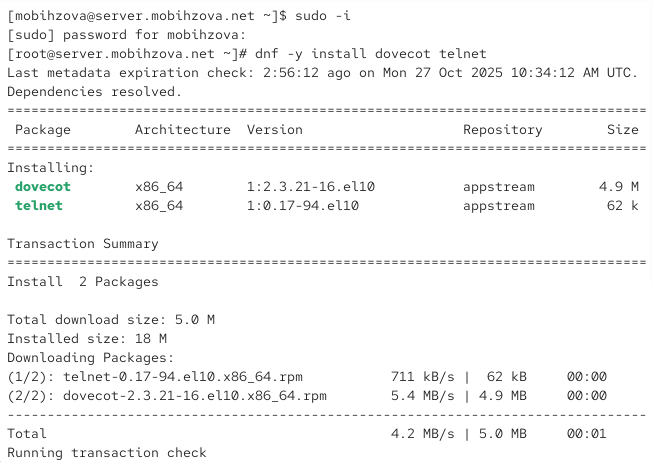

Рисунок 1: Установка пакетов dovecot и telnet на сервере

## Настройка Dovecot

В конфигурационном файле `/etc/dovecot/dovecot.conf` пропишем список почтовых протоколов, по которым разрешено работать Dovecot (рис. 2)

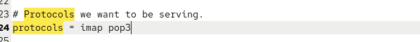

Рисунок 2: Настройка протоколов в dovecot.conf

## Настройка Dovecot

В конфигурационном файле `/etc/dovecot/conf.d/10-auth.conf` проверяем, что указан метод аутентификации plain (рис. 3)

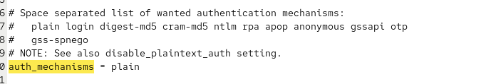

Рисунок 3: Настройка аутентификации в 10-auth.conf

## Настройка Dovecot

В конфигурационном файле `/etc/dovecot/conf.d/auth-system.conf.ext` проверяем, что для поиска пользователей и их паролей используется pam и файл passwd (рис. 4, рис. 5)

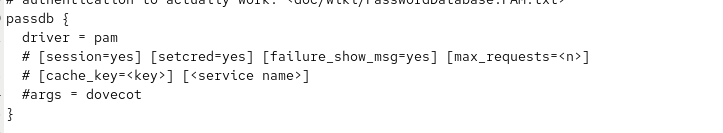

Рисунок 4: Настройка passdb в auth-system.conf.ext

## Настройка Dovecot

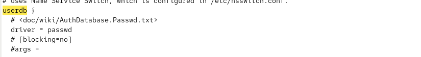

Рисунок 5: Настройка userdb в auth-system.conf.ext

## Настройка Dovecot

В конфигурационном файле `/etc/dovecot/conf.d/10-mail.conf` настраиваем месторасположение почтовых ящиков пользователей (рис. 6)

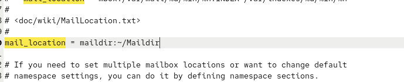

Рисунок 6: Настройка расположения почтовых ящиков

## Настройка Dovecot

В Postfix задаём каталог для доставки почты (рис. 7)

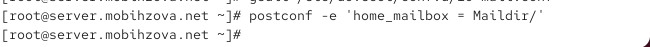

Рисунок 7: Настройка home_mailbox в Postfix

## Настройка межсетевого экрана

Сконфигурируем межсетевой экран, разрешив работать службам протоколов POP3 и IMAP (рис. 8)

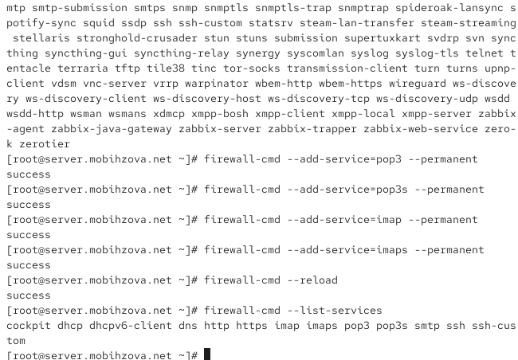

Рисунок 8: Настройка firewall для POP3/IMAP

## Настройка SELinux и запуск служб

Восстановим контекст безопасности в SELinux (рис. 9)

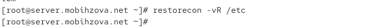

Рисунок 9: Восстановление контекстов SELinux

## Настройка SELinux и запуск служб

Перезапустим Postfix и запустим Dovecot (рис. 10).

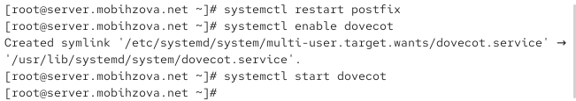

Рисунок 10: Перезапуск Postfix и запуск Dovecot

## Проверка работы Dovecot

Запустим мониторинг работы почтовой службы (рис. 11)

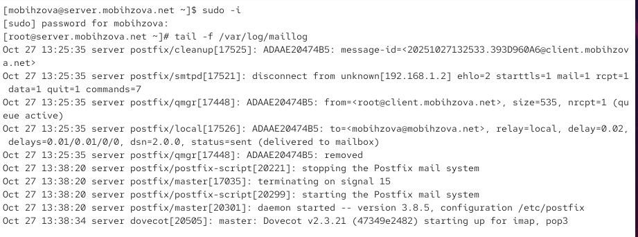

Рисунок 11: Мониторинг почтовой службы

## Проверка работы Dovecot

Проверим наличие почты для пользователя и список mailbox’ов (рис. 12)

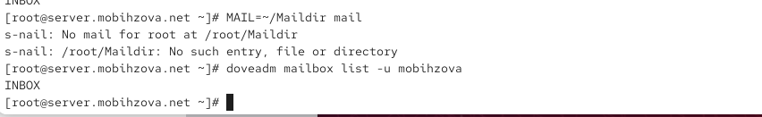

Рисунок 12: Проверка почты и mailbox’ов

## Установка Evolution на клиенте

На виртуальной машине client установим почтовый клиент Evolution (рис. 13)

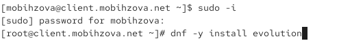

Рисунок 13: Установка Evolution на клиенте

## Настройка Evolution

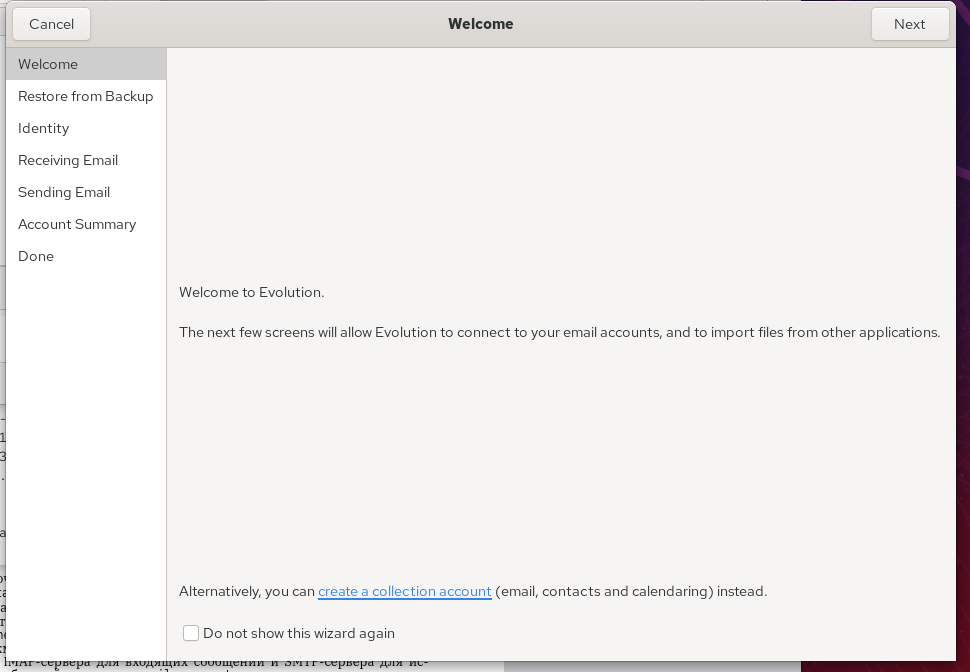

Рисунок 14: Начало настройки Evolution

## Настройка Evolution

Заполним данные идентификации (рис. 15)

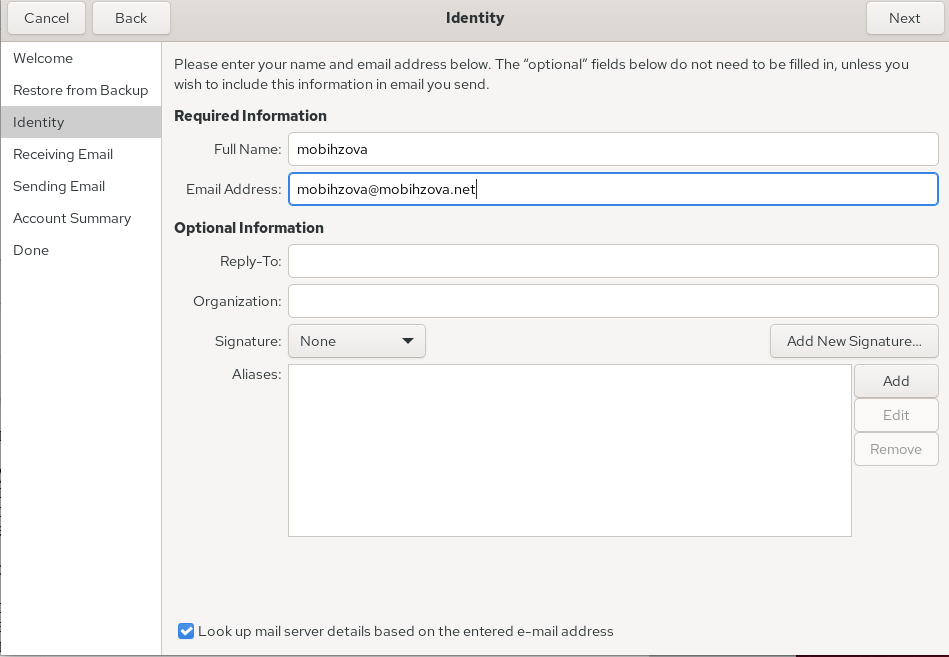

Рисунок 15: Заполнение идентификации в Evolution

## Настройка Evolution

Настроим параметры получения почты (IMAP) (рис. 16)

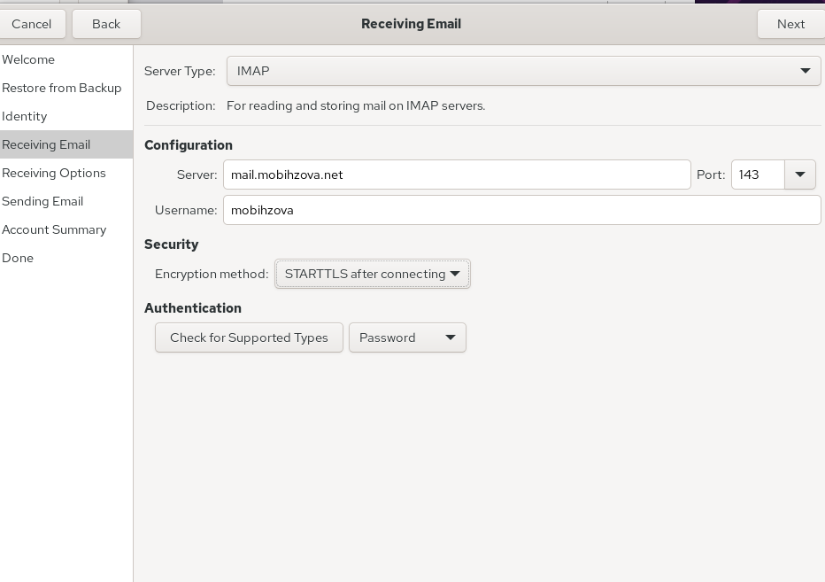

Рисунок 16: Настройка получения почты в Evolution

## Настройка Evolution

Настроим параметры отправки почты (SMTP) (рис. 17)

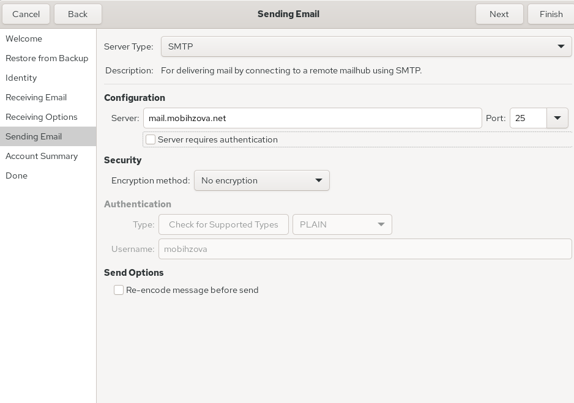

Рисунок 17: Настройка отправки почты в Evolution

## Настройка Evolution

Просмотрим сводку настроек (рис. 18)

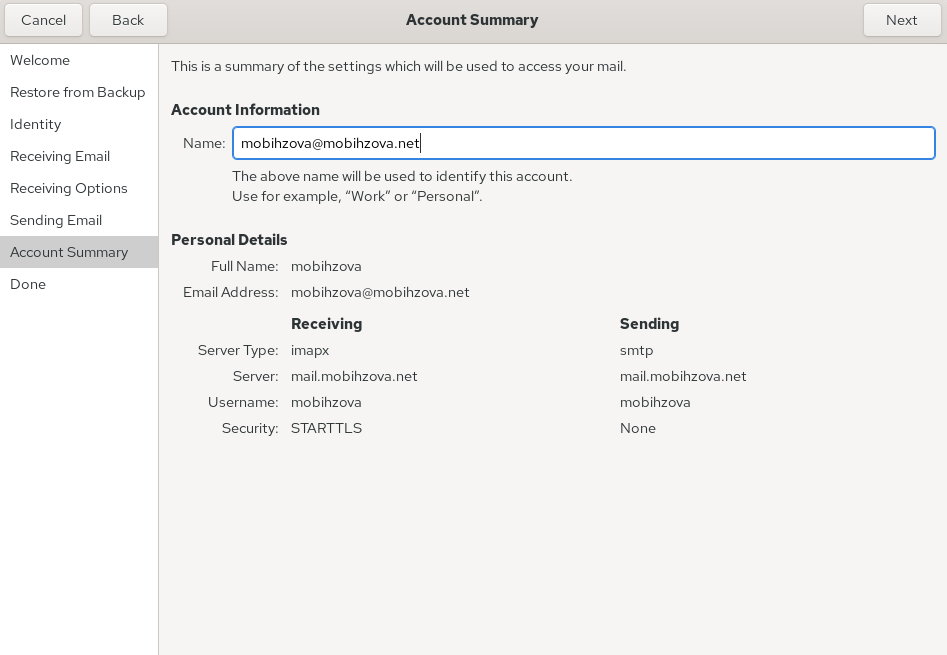

Рисунок 18: Сводка настроек Evolution

## Настройка Evolution

При возникновении сообщения о небезопасном соединении подтвердим исключение безопасности (рис. 19)

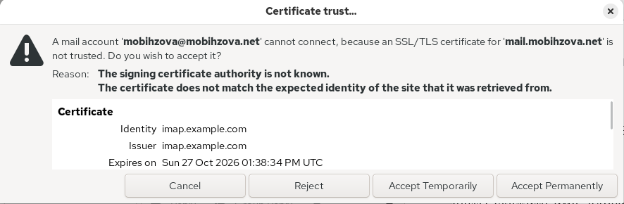

Рисунок 19: Подтверждение SSL-сертификата

## Проверка работы почтовой системы

Из почтового клиента отправляем себе несколько тестовых писем и убеждаемся, что они доставлены (рис. 20).

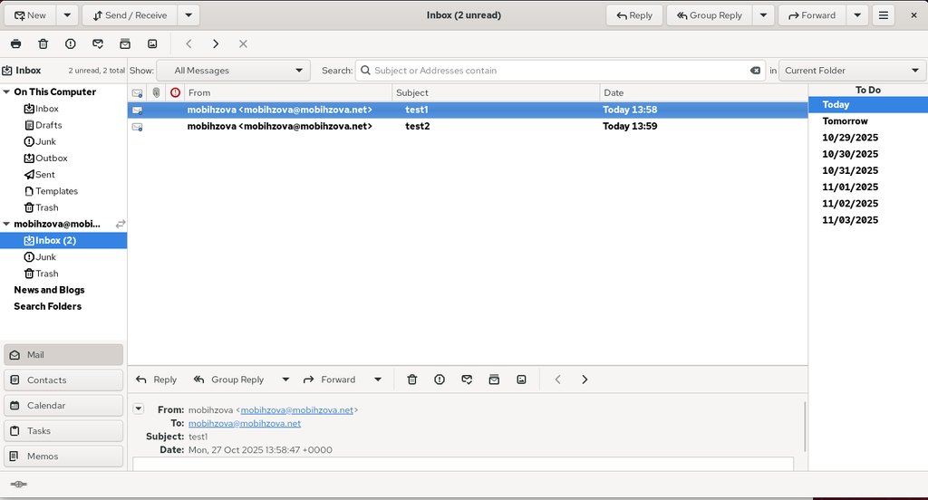

Рисунок 20: Проверка доставки писем в Evolution

## Проверка работы почтовой системы

Параллельно смотрим, какие сообщения выдаются при мониторинге почтовой службы на сервере (рис. 21)

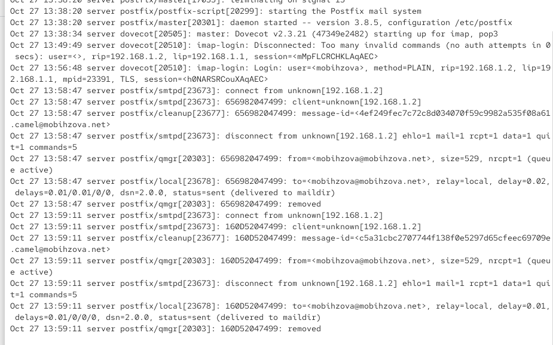

Рисунок 21: Логи доставки писем

## Проверка работы почтовой системы

Проверяем наличие почты через командную строку (рис. 22)

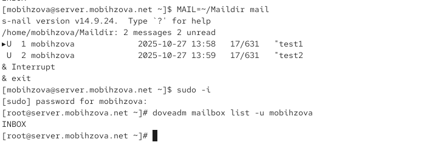

Рисунок 22: Проверка почты через mail

## Проверка работы через Telnet

Проверяем работу почтовой службы, используя на сервере протокол Telnet. Подключаемся к почтовому серверу по протоколу POP3 и проходим аутентификацию (рис. 23)

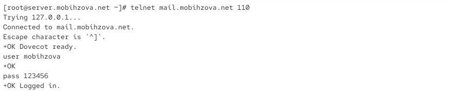

Рисунок 23: Подключение к POP3 через Telnet

## Проверка работы через Telnet

Получаем первое письмо из списка (рис. 24)

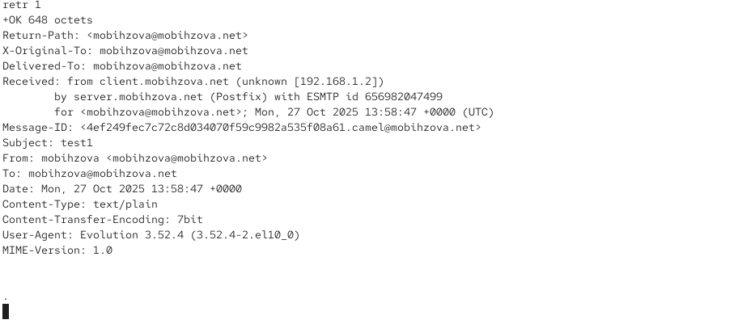

Рисунок 24: Получение письма через Telnet

## Проверка работы через Telnet

Удаляем второе письмо из списка и завершаем сеанс (рис. 25)

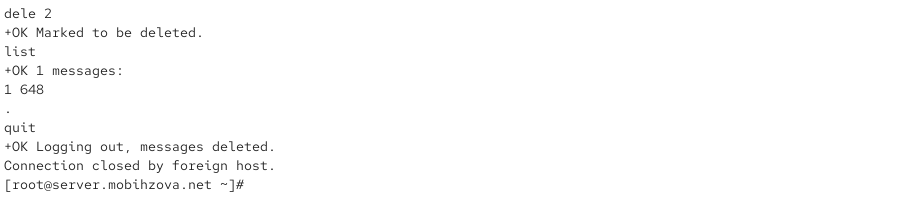

Рисунок 25: Удаление письма и завершение сеанса

## Внесение изменений в настройки внутреннего окружения виртуальной машины

На виртуальной машине server переходим в каталог для внесения изменений в настройки внутреннего окружения и копируем конфигурационные файлы Dovecot (рис. 26)

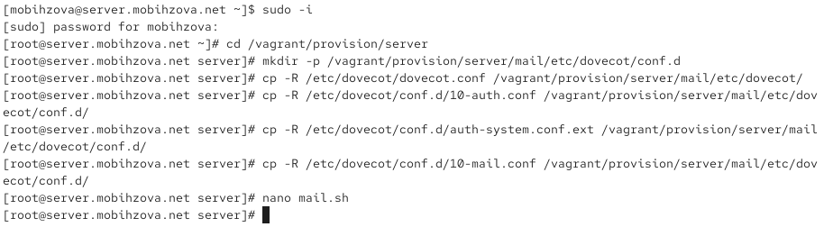

Рисунок 26: Копирование конфигурационных файлов Dovecot

## Внесение изменений в настройки внутреннего окружения виртуальной машины

Вносим изменения в файл `/vagrant/provision/server/mail.sh`, добавляя в него строки по установке Dovecot и Telnet, настройке межсетевого экрана и запуску служб (рис. 27)

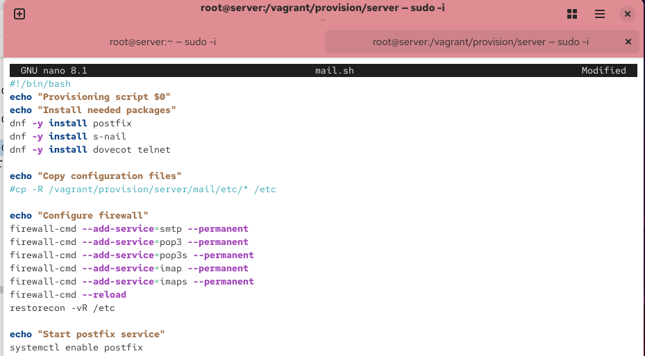

Рисунок 27: Настройка скрипта mail.sh для сервера

## Внесение изменений в настройки внутреннего окружения виртуальной машины

На виртуальной машине client в каталоге `/vagrant/provision/client` корректируем файл mail.sh, прописывая в нём установку Evolution (рис. 28)

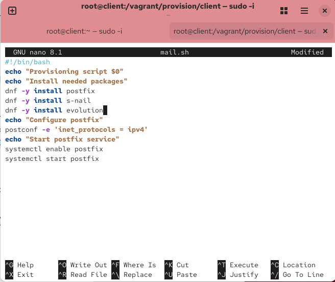

Рисунок 28: Настройка скрипта mail.sh для клиента

# Выводы

## Выводы

В ходе выполнения данной лабораторной работы я приобрела практические навыки по установке и простейшему конфигурированию POP3/IMAP-сервера.